# El VAR dentro del fútbol

Pedro Alan Velázquez Romero

4/21/2022

### 1. JUSTIFICACIÓN

El VAR es una herramienta tecnológica de reciente implementación dentro del fútbol que promete grandes avances en cuanto a decisiones arbitrales en cada partido que se juegue, sin embargo, existe la disputa de aquellos que afirman que el VAR en realidad no aporta nada extra al fútbol, incluso hay algunas personas que llegan a afirmar que éste funge más como un detractor del fútbol que una ayuda al mismo. Sobre este debate es que se inspira al realizar la presente investigación, para así poder afirmar, o negar, con datos, dichas declaraciones hacia con el VAR. Por lo tanto, lo que se busca aquí es descubrir el verdadero aporte del VAR dentro del fútbol profesional.

### 2. DELIMITACIÓN DEL PROBLEMA

“El efecto (papel/desempeño) del VAR dentro de partidos oficiales del fútbol profesional inglés desde su implementación (2019) al día de hoy”

- **Espacial**: Inglaterra - Premier League (PL)
- **Temporal**: 2016-2022 (Tomando en cuenta solamente partidos oficiales de la PL)

### 3. OBJETIVOS

#### 3.1 Generales

Analizar el efecto del VAR dentro de partidos oficiales del fútbol profesional inglés desde su implementación (2019) al día de hoy

#### 3.2 Específicos

1. Analizar efecto en el dinamismo de los equipos dentro de cada partido que juegan
2. Analizar efecto en generación de oportunidades de gol, ¿Los jugadores toman mayores riesgos en equipo con la presencia del VAR?
3. Analizar efecto en individualidades y trabajo en equipo
4. ¿Realmente se genera **justicia deportiva** con el VAR?

### 4. PREGUNTA DE INVESTIGACIÓN

¿Cuáles son las ventajas y desventajas de la implementación del VAR dentro de los partidos en el fútbol profesional inglés?

El VAR es la herramienta tecnológica más reciente que se ha implementado dentro del fútbol profesional en todo el mundo. El propósito pricipal de esta implementación es generar mayor justicia deportiva en cada partido de fútbol con respecto a decisiones arbitrales, sin embargo, al ser una herramienta dce tecnología moderna y totalmente nueva dentro del ambiente del fútbol, ésta puede presentar mayores fallas en su funcionamiento y esto, a su vez, puede llegar a ocasionar mayores repercusiones dentro del fútbol y el desarrollo de los partidos (en dinamismo, desempeño de los equipos, etc.).

Por lo tanto, es impoprtante hacer un análisis acerca de las ventajas y desventajas que ha traído el VAR hasta el día de hoy dentro del fútbol y con ello poder discernir sobre si es una herramienta que vale la pena implementar dentro del fútbol moderno.

### 5. HIPÓTESIS

Si bien el VAR es una herramienta que permite grandes avances tecnológicos y arbitrales dentro del fútbol moderno, es bien sabido que su desempeño no ha sido la óptima dentro de cada partido de fútbol. En varias ocasiones se ha podido observar que el VAR ha generado más complicaciones en cada partido de fútbol, por ejemplo, pérdida de tiempo de jugo a la hora de consultar el VAR, malas intervenciones del VAR en decisiones arbitrales (tanto en equivocaciones a la hora de tomar la decisión arbitral, como en negligencia de intervención cuando se necesita, entre otros).

Con ello, se podría llegar a pensar que el VAR está trayendo consigo más aspectos negativos que positivos en el fútbol moderno, así, la hipótesis central de esta investigación es la siguiente:

**El VAR influye negativamente en el desarrollo de los partidos profesionales de fútbol inglés ,desde su implementación, hasta el día de hoy**

### 6. DESARROLLO

#### 6.1 Análisis exploratorio

Como primer acercamiento hacia la prueba de la hipótesis planteada anteriormente, se analizarán los datos que nos arrojó, por una parte, el fútbol profesional jugado en Inglaterra desde la temporada 2016/2017 hasta el día de hoy (temporada 2021/2022), y por otro lado, el desempeño del VAR dentro de esta misma liga profesional de fútbol desde la temporada 2019/2020 (pimera implementación) hasta el día de hoy (temporada 2021/2022).

A su vez, como se planteó desde el punto 3, la intención del presente análisis sobre el VAR va dirigida hacia con el dinamismo de los equipos de fútbol, y por consiguiente de los partidos, dentro de la liga profesional de Inglaterra. Por lo tanto, algunos de los puntos que se pretenden lograr analizar son los siguientes:

1. Dinámica de pases dentro del equipo (pass map)
2. Dinámica de movimientos del equipo, dividido en lo siguiente:
   - Fatiga de los jugadores como parte del dinamismo del juego
   - Número de pases, goles, asistencias en campo contrario: ¿Qué tanto se crea en el campo contrario?
   - Formaciones y tipo de agrupaciones que toman los equipos a la hora de defender: La defensa como parte del dinamismo del equipo
   - Número de faltas cometidas por equipo durante el partido: Número de intervenciones del VAR
   - La dinámica del equipo para con la “estrella” de cada equipo. ¿Juegan con base en él o lejos de él?
   - Número de encaramientos durante el partido: ¿Qué tanto se da el juego 1 vs 1 durante el partido?, ¿cuántos de ellos terminan en gol?
3. Analizar el trabajo en conjunto de todos los involucrados en el equipo: Qué tanto ocasiona el VAR que se juegue a base de más individualidades.

A continuación, se analizarán, por separado, cada uno de los puntos mencionados.

##### 6.1.1 Dinámica de pases

La dinámica de pases en el fútbol se entiende aquí como la manera o el comportamiento de los pases que los jugadores hacen dentro de cada partido hacia con sus compañeros. Esta dinámica se puede dividir, a su vez, en los siguientes tipos de pases que pueden suceder dentro de un partido de fútbol:

1. Pases hacia enfrente (hacia campo contrario)
2. Pases hacia atrás (hacia propio campo)
3. Pases laterales (posibles cambios de juego) (nsxg1)
4. Asistencias

La dinámica de los **pases hacia enfrente** los analizaremos con la ayuda de las siguientes variables:

**Comportamiento esperado según hipótesis:** Una disminución de pases hacia enfrente con la llegada del VAR

###### **Asistencias**

La primera variable que tomamos en cuenta dentro de este rubro es el número de asistencias que realizan los diferentes equipos de la PL. En primera instancia, revisaremos el total de asistencias hechas por los jugadores jornada a jornada desde la temporada 16/17 hasta la temporads 21/22, esto con el motivo de analizar el comportamiento general de las asistencias en los partidos y poder observar, con algo de suerte, un comportamiento “extraño” del total de asistencias por jornada y así poder enfocar nuestro análisis en ciertas jornadas.

La primera gráfica que analizaremos será la suma de asistencias por jornada durante todas las temporadas por analizar, es decir, desde la temporada 16/17 hasta la temporada 21/22.

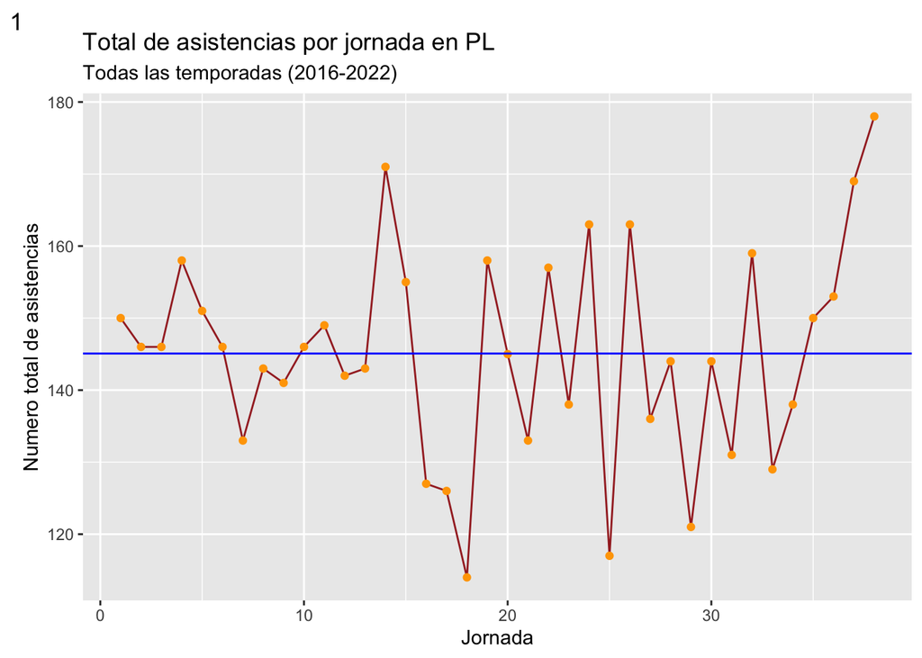

```r
plt_assists
```

Esta pequeña gráfica de series de tiempo sobre el total de asistencias hechas por jornada dentro de la PL muestra algunos resultados interesante, por ejemplo, podemos observar que de manera general, el comportamiento del total de las asistencias dentro de las primeras 10 o 13 jornadas se mantiene muy cerca de la media (145.0789474 asistencias) y a partir de esa jornada, el comportamiento general de las asistencias tiene variaciones más *aleatorias* entre cada jornada, es decir, el comportamiento ya no es tan predecible y existen tanto picos muy bajos, como algunos muy altos. Esto último podría explicarse de manera lógica ya que por lo general, al inicio de cada temporada, todos los equipos tienden a atreverse menos al ataque debido a que son jornadas en que los jugadores tratan de empezar a tener esa cohesión de equipo y, a la vez, son jornadas en que la presión por posiciones en las tablas (y por otras competencias europeas) es más pequeña en comparación de la mitad de la temporada en adelante.

Ahora, veremos si es que este comportamiento se sigue mostrando tomando en cuenta la variable de interés en esta investigación: el VAR, esta medición se hará con base a la temporada por analizar, ya que sabemos que el VAR fue introducido a la PL a partir de la temporada 19/20.

**Número de asistencias en temporadas pre-VAR vs temporadas post-VAR**

Como primer acercamiento, graficaremos el total de asistencias por jornada (al igual que en el gráfico anterior) pero ahora dividiéndolo por temporada, esto simplemente para poder tener mejor visibilidad del comportamiento de las asistencias hechas en cada temporada pre-VAR y post-VAR.

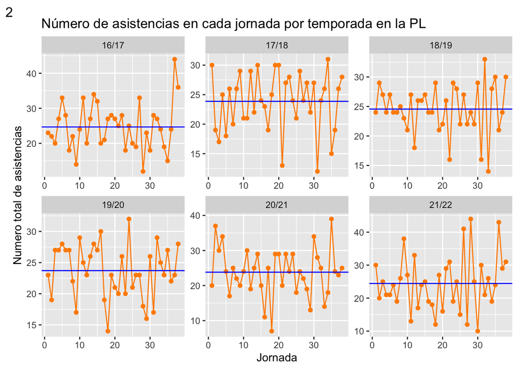

```r
plt_assists_seasons
```

Ahora, con la intención de poder observar precisamente un cambio, ya sea a la alza o a la baja, en el número de asistencias en temporadas pre-VAR vs post-VAR, se elaborará un gráfico en donde se comparen estos dos tipos de temporadas con base en su total de asistencias jornada tras jornada.

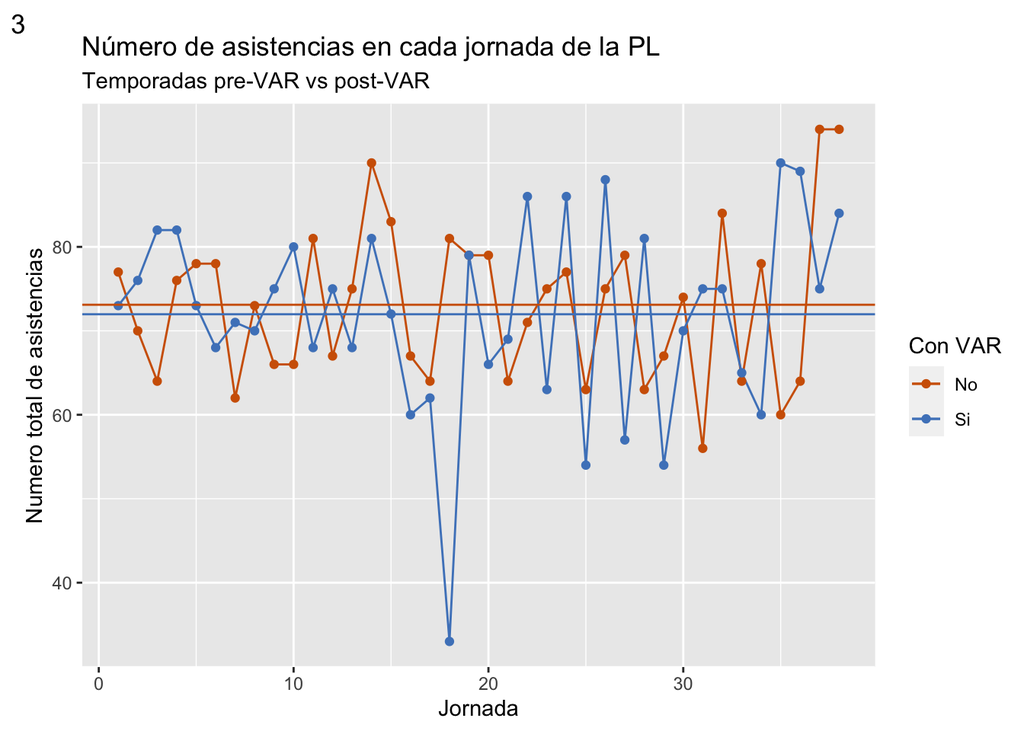

```r
plt_assists_var
```

Una vez obtenida la gráfica de la comparación de estos dos tipos de temporadas (post-VAR y pre-VAR) podemos observar lo que ya se sospechaba en la gráfica nñumero 2: el comportamiento de las asistencias dentro de temporadas con VAR es más “aleatoria”, presenta picos más grandes y no se mantiene dentro de un cierto rango, mientras que el comportamiento de las asistencias en temporadas sin VAR el comportamiento es más homogeneo, se mantiene dentro de un límite muy cerca de su media (línea naranja) y no es tan cambiante. Por último, de manera general podemos observar que la línea de la media para las temporadas con VAR (azul) se mantiene por debajo de la línea de la media para las temporadas sin VAR (naranja), por lo que, con esta “prueba” gráfica podríamos empezar a sospechar un poco más a favor de nuestra hipótesis inicial: el VAR provoca una reducción en el número de asistencias hechas en cada partido de la PL.

Hasta este momento, con estas gráficas que pudimos analizar brevemente sobre nuestra primera variable, podemos fallar a favor de nuestra hipótesis inicial. Nuestra siguiente variable es el número de pases intentados que se realizan dentro de cada partido.

###### **Pases intentados (attempted_passes)**

La siguiente variable que analizaremos será el número de pases que se intentaron dar durante cada partido, esto con el fin de analizar la dinámica de los mismos partidos. El número de pases intentados durante el partido nos pueden dar una percepción de como es que los equipos, en primer lugar, tuvieron el control del partido en cuanto a posición del balón se refiere y, en segundo lugar, si un equipo realiza muchos intentos de pase podríamos llegar a pensar que tiene la disposición de crear juego durante el partido y, por lo tanto, llegar a tener una mejor dinámica de juego. Por lo tanto, tomando en cuenta nuestra hipótesis central, lo que podemos llegar a pensar es que, con la implementación del VAR, el número de pases intentados durante los partidos redujo.

$$NP = \left[\frac{AS + AP + CP + KP +
OPC}{5}\right]\left[\frac{(POS)(MIN)}{100}\right]$$
Donde:

- NP = Número de pases, representa el total de pases hechos durante la temporada, jornada, etc.
- AS = Número de asistencias, representa el total de asistencias hechas durante la temporada, jornada, etc.
- AP = Número de pases intentados, representa el total de pases intentados durante la temporada, jornada, etc.
- CP = Número de pases completados, representa el total de pases completados durante la temporada, jornada, etc.
- KP = Número de pases clave, representa el total de pases claves hechos durante la jornada, temporada, etc.
- OPC = Número de jugadas cruzadas, representa el total de cruces de juego hechos durante la jornada, temporada, etc.
- POS = Tiempo de posesión del balón durante cada partido, representa el total de tiempo que el equipo tuvo posesión del balón durante cada partido. Se divide entre 100 para tener un numero entre cero y uno.
- MIN = Número de minutos que disputó el jugador dentro del partido (si aplica). Se toma en cuenta para tener una proporción más confiable de la aportación del jugador/equipo al partido.

Debido a que el interés de este análisis es la comparación de la temporada pre-VAR vs post-VAR a nivel jornada (GW) y temporada, las métricas antes mencionadas se medirán/agruparán a nivel equipo (en caso de no contar con info del equipo visitante, se tomará en cuenta siempre el equipo local). Si no se tiene información del nombre del equipo local entonces se le asignará el valor del porcentaje de posesión igual al promedio obtenido en la jornada, temporada, o cual sea la variable de agrupación en el análisis. Antes de la agrupación a nivel equipo o jornada, los cálculos se harán a nivel jugador para después hacer la variable agregada.

```r
poss_season_gw
```

```
## # A tibble: 228 × 3
## # Groups:   season [6]
##    season    GW avg_poss
##    <chr>  <dbl>    <dbl>
##  1 16/17      1     47.7
##  2 16/17      2     47.6
##  3 16/17      3     47.5
##  4 16/17      4     47.6
##  5 16/17      5     47.6
##  6 16/17      6     47.6
##  7 16/17      7     47.6
##  8 16/17      8     47.7
##  9 16/17      9     47.7
## 10 16/17     10     47.7
## # … with 218 more rows
```

```r
#creamos el df con los valores promedio de posesión por jornada
fpl_gw <- fpl_gw %>% mutate(np = (assists+attempted_passes+completed_passes+key_passes+open_play_crosses)*minutes*(poss/100)/5)
```

La primer gráfica que elaboraremos será, al igual que con la primera variable analizada, una serie de tiempo del número de pases intentados jornada tras jornada dividiendo las temporadas pre-VAR y post-VAR para así analizar el comportamiento de esta variable con el paso del tiempo con y sin presencia del VAR. Por la manera en que tenemos la data disponible, haremos uso de dos variables al mismo tiempo, por un lado, en temporadas donde el VAR aún no estaba implementado dentro de la EPL, se utilizaba la medición *attempted_passes* y, por el otro, en temporadas donde el VAR ya estaba implementado, se utiliza la medición *xP* el cual denota el número de pases esperados que realice el jugador de acuerdo a su desempeño dentro de cada partido y de algunas otras variables. Estas dos variables las podemos pensar como similares pero no iguales, debido a que expresan la misma esencia: el pase de balón dentro de cada partido, pero la manera en que se miden no es exactamente la misma, con esto, podemos decir que los resultados que obtengamos a partir de este momento sobre esta variable: *numero de pases intentados* no serán al cien porciento confiables y demostrativas pero nos pueden generar una muy buena percepción de la misma.

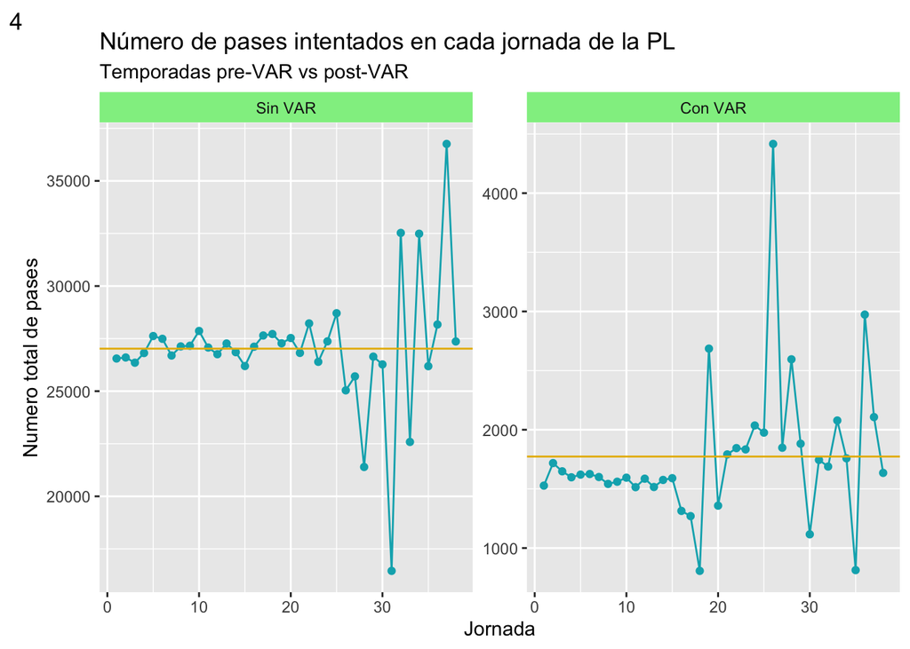

```r
plt_passes_gw
```

Al obtener la gráfica podemos observar en primera instancia que la media de pases intentados (línea amarilla en ambas gráficas) para las temporadas sin VAR es en general más alta que la de las temporadas con VAR, esto en primera instancia nos dice que los equipos intentaban generar, en promedio, más pases (y por ende mayor dinamismo de juego) y procuraban quedarse menos con el balón para jugadas individuales antes del VAR. Otro aspecto importante a observar dentro de esta gráfica es que los registros del número de pases para temporadas sin VAR parecen quedarse muy pegados a la línea que representa la media al menos en las primeras 25 jornadas aprox., después de ahí el comportamiento parece dispararse un poco hacia abajo y después repunta hacia el final de la temporada; por otro lado, para las temporadas en donde ya existe el VAR, el número de pases intentados parece mantenerse siempre debajo de la media hasta aprox. la jornada 20 que es donde éste toma un comportamiento muy aleatorio al presentar picos muy altos y muy bajos en periodos cortos de tiempo.

Con todo lo anterior podríamos designarle de manera general un comportamiento más aleatorio al número de pases intentados para aquellas temporadas con VAR y por debajo del número de pases en temporadas sin VAR (al menos en cuanto al promedio de pases), es decir, una **disminución del intento de pases con la llegada del VAR**.

A manera de reforzar la sospecha de que el número de pases intentados redujo en temporadas donde el VAR ya estaba incluido en la PL, graficaremos el área representativa al % del numero de pases intentados por jornada en temporadas sin VAR y con VAR, esto con el fin de ver qué tanto aporta el número de pases intentados en temporadas con VAR con respecto al total.

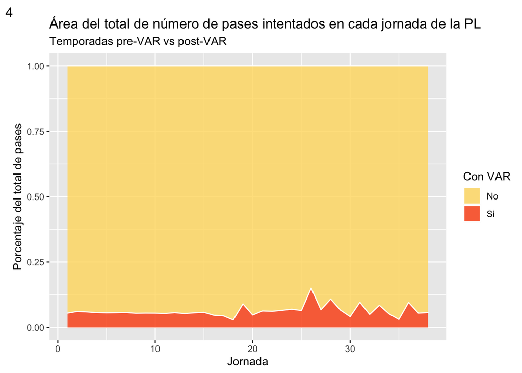

```r
plt_area_apass
```